# Optimal Treatment Analysis

## Outcome Variable

**Outcome Variable:** whz

## Predictor Variables

**Intervention Variable:** parity

**Adjustment Set:**

- arm
- W_mage
- meducyrs
- feducyrs
- W_mhtcm
- vagbrth
- single
- impsan
- delta_W_mage
- delta_meducyrs
- delta_feducyrs
- delta_W_mhtcm
- delta_vagbrth
- delta_single
- delta_impsan

## Stratifying Variables

The analysis was stratified on these variable(s):

- agecat
- studyid
- country

## Data Summary

| agecat | studyid | country | parity | n_cell | n |
| --- | --- | --- | --- | --- | --- |
| Birth | ki1000304b-SAS-CompFeed | INDIA | 1 | 18 | 61 |
| Birth | ki1000304b-SAS-CompFeed | INDIA | 2 | 11 | 61 |
| Birth | ki1000304b-SAS-CompFeed | INDIA | 3+ | 32 | 61 |
| Birth | ki1101329-Keneba | GAMBIA | 1 | 142 | 1292 |
| Birth | ki1101329-Keneba | GAMBIA | 2 | 133 | 1292 |
| Birth | ki1101329-Keneba | GAMBIA | 3+ | 1017 | 1292 |
| Birth | ki1126311-ZVITAMBO | ZIMBABWE | 1 | 5561 | 12915 |
| Birth | ki1126311-ZVITAMBO | ZIMBABWE | 2 | 3882 | 12915 |
| Birth | ki1126311-ZVITAMBO | ZIMBABWE | 3+ | 3472 | 12915 |
| Birth | ki1135781-COHORTS | GUATEMALA | 1 | 50 | 375 |
| Birth | ki1135781-COHORTS | GUATEMALA | 2 | 65 | 375 |
| Birth | ki1135781-COHORTS | GUATEMALA | 3+ | 260 | 375 |
| Birth | ki1135781-COHORTS | INDIA | 1 | 641 | 3855 |
| Birth | ki1135781-COHORTS | INDIA | 2 | 982 | 3855 |
| Birth | ki1135781-COHORTS | INDIA | 3+ | 2232 | 3855 |
| Birth | ki1135781-COHORTS | PHILIPPINES | 1 | 640 | 2899 |
| Birth | ki1135781-COHORTS | PHILIPPINES | 2 | 657 | 2899 |
| Birth | ki1135781-COHORTS | PHILIPPINES | 3+ | 1602 | 2899 |
| Birth | kiGH5241-JiVitA-3 | BANGLADESH | 1 | 2255 | 7676 |
| Birth | kiGH5241-JiVitA-3 | BANGLADESH | 2 | 2730 | 7676 |
| Birth | kiGH5241-JiVitA-3 | BANGLADESH | 3+ | 2691 | 7676 |
| 6 months | ki1000304b-SAS-CompFeed | INDIA | 1 | 124 | 411 |
| 6 months | ki1000304b-SAS-CompFeed | INDIA | 2 | 90 | 411 |
| 6 months | ki1000304b-SAS-CompFeed | INDIA | 3+ | 197 | 411 |
| 6 months | ki1000304b-SAS-FoodSuppl | INDIA | 1 | 18 | 94 |
| 6 months | ki1000304b-SAS-FoodSuppl | INDIA | 2 | 18 | 94 |
| 6 months | ki1000304b-SAS-FoodSuppl | INDIA | 3+ | 58 | 94 |
| 6 months | ki1017093b-PROVIDE | BANGLADESH | 1 | 211 | 582 |
| 6 months | ki1017093b-PROVIDE | BANGLADESH | 2 | 212 | 582 |
| 6 months | ki1017093b-PROVIDE | BANGLADESH | 3+ | 159 | 582 |

[output cut: 51 more lines]

The following strata were considered:

- agecat: 24 months, studyid: ki1017093b-PROVIDE, country: BANGLADESH
- agecat: 24 months, studyid: ki1066203-TanzaniaChild2, country: TANZANIA, UNITED REPUBLIC OF
- agecat: 24 months, studyid: ki1101329-Keneba, country: GAMBIA
- agecat: 24 months, studyid: ki1113344-GMS-Nepal, country: NEPAL
- agecat: 24 months, studyid: ki1126311-ZVITAMBO, country: ZIMBABWE
- agecat: 24 months, studyid: ki1135781-COHORTS, country: GUATEMALA
- agecat: 24 months, studyid: ki1135781-COHORTS, country: INDIA
- agecat: 24 months, studyid: ki1135781-COHORTS, country: PHILIPPINES
- agecat: 24 months, studyid: kiGH5241-JiVitA-3, country: BANGLADESH
- agecat: 6 months, studyid: ki1000304b-SAS-CompFeed, country: INDIA
- agecat: 6 months, studyid: ki1000304b-SAS-FoodSuppl, country: INDIA
- agecat: 6 months, studyid: ki1017093b-PROVIDE, country: BANGLADESH
- agecat: 6 months, studyid: ki1066203-TanzaniaChild2, country: TANZANIA, UNITED REPUBLIC OF
- agecat: 6 months, studyid: ki1101329-Keneba, country: GAMBIA
- agecat: 6 months, studyid: ki1113344-GMS-Nepal, country: NEPAL
- agecat: 6 months, studyid: ki1126311-ZVITAMBO, country: ZIMBABWE
- agecat: 6 months, studyid: ki1135781-COHORTS, country: GUATEMALA
- agecat: 6 months, studyid: ki1135781-COHORTS, country: INDIA
- agecat: 6 months, studyid: ki1135781-COHORTS, country: PHILIPPINES
- agecat: 6 months, studyid: kiGH5241-JiVitA-3, country: BANGLADESH
- agecat: Birth, studyid: ki1000304b-SAS-CompFeed, country: INDIA
- agecat: Birth, studyid: ki1101329-Keneba, country: GAMBIA
- agecat: Birth, studyid: ki1126311-ZVITAMBO, country: ZIMBABWE
- agecat: Birth, studyid: ki1135781-COHORTS, country: GUATEMALA
- agecat: Birth, studyid: ki1135781-COHORTS, country: INDIA
- agecat: Birth, studyid: ki1135781-COHORTS, country: PHILIPPINES
- agecat: Birth, studyid: kiGH5241-JiVitA-3, country: BANGLADESH

### Dropped Strata

Some strata were dropped due to rare outcomes:

- agecat: 24 months, studyid: ki1066203-TanzaniaChild2, country: TANZANIA, UNITED REPUBLIC OF

## Methods Detail

We’re interested in the causal parameters $E[Y_a]$ for all values of $a \in \mathcal{A}$. These parameters represent the mean outcome if, possibly contrary to fact, we intervened to set all units to have $A=a$. Under the randomization and positivity assumptions, these are identified by the statistical parameters $\psi_a=E_W[E_{Y|A,W}(Y|A=a,W)]$. In addition, we’re interested in the mean of $Y$, $E[Y]$ under no intervention (the observed mean). We will estimate these parameters by using SuperLearner to fit the relevant likelihood factors – $E_{Y|A,W}(Y|A=a,W)$ and $p(A=a|W)$, and then updating our likelihood fit using a joint TMLE.

For unadjusted analyses ($W=\{\}$), initial likelihoods were estimated using Lrnr_glm to estimate the simple $E(Y|A)$ and Lrnr_mean to estimate $p(A)$. For adjusted analyses, a small library containing Lrnr_glmnet, Lrnr_xgboost, and Lrnr_mean was used.

Having estimated these parameters, we will then use the delta method to estimate relative risks and attributable risks relative to a prespecified baseline level of $A$.

# Results Detail

## Results Plots

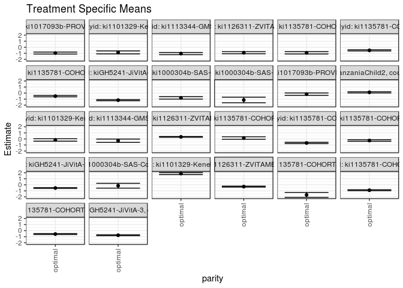

## Results Table

### Parameter: TSM

| agecat | studyid | country | intervention_level | baseline_level | estimate | ci_lower | ci_upper |
| --- | --- | --- | --- | --- | --- | --- | --- |
| Birth | ki1000304b-SAS-CompFeed | INDIA | optimal | observed | -0.1554837 | -0.5545648 | 0.2435975 |
| Birth | ki1101329-Keneba | GAMBIA | optimal | observed | 1.8614156 | 1.7022845 | 2.0205467 |
| Birth | ki1126311-ZVITAMBO | ZIMBABWE | optimal | observed | -0.3007014 | -0.3790242 | -0.2223787 |
| Birth | ki1135781-COHORTS | GUATEMALA | optimal | observed | -1.6740660 | -2.0842415 | -1.2638904 |
| Birth | ki1135781-COHORTS | INDIA | optimal | observed | -0.8989502 | -0.9785517 | -0.8193487 |
| Birth | ki1135781-COHORTS | PHILIPPINES | optimal | observed | -0.5633776 | -0.6367806 | -0.4899746 |
| Birth | kiGH5241-JiVitA-3 | BANGLADESH | optimal | observed | -0.7606729 | -0.8275460 | -0.6937999 |
| 6 months | ki1000304b-SAS-CompFeed | INDIA | optimal | observed | -0.7962686 | -0.9963421 | -0.5961951 |
| 6 months | ki1000304b-SAS-FoodSuppl | INDIA | optimal | observed | -1.1479573 | -1.6127109 | -0.6832037 |
| 6 months | ki1017093b-PROVIDE | BANGLADESH | optimal | observed | -0.1755136 | -0.3711878 | 0.0201606 |
| 6 months | ki1066203-TanzaniaChild2 | TANZANIA, UNITED REPUBLIC OF | optimal | observed | 0.1239667 | 0.0182530 | 0.2296804 |
| 6 months | ki1101329-Keneba | GAMBIA | optimal | observed | -0.1666253 | -0.3682513 | 0.0350008 |
| 6 months | ki1113344-GMS-Nepal | NEPAL | optimal | observed | -0.2931417 | -0.5694708 | -0.0168127 |
| 6 months | ki1126311-ZVITAMBO | ZIMBABWE | optimal | observed | 0.3417496 | 0.2778201 | 0.4056791 |
| 6 months | ki1135781-COHORTS | GUATEMALA | optimal | observed | 0.1490853 | -0.0577587 | 0.3559293 |
| 6 months | ki1135781-COHORTS | INDIA | optimal | observed | -0.6665212 | -0.7725624 | -0.5604800 |
| 6 months | ki1135781-COHORTS | PHILIPPINES | optimal | observed | -0.2645147 | -0.3933653 | -0.1356641 |
| 6 months | kiGH5241-JiVitA-3 | BANGLADESH | optimal | observed | -0.5333586 | -0.6068665 | -0.4598508 |
| 24 months | ki1017093b-PROVIDE | BANGLADESH | optimal | observed | -0.9650085 | -1.1321900 | -0.7978269 |
| 24 months | ki1101329-Keneba | GAMBIA | optimal | observed | -0.8577764 | -1.1029977 | -0.6125551 |
| 24 months | ki1113344-GMS-Nepal | NEPAL | optimal | observed | -1.0550368 | -1.2318770 | -0.8781966 |
| 24 months | ki1126311-ZVITAMBO | ZIMBABWE | optimal | observed | -0.9110402 | -1.0857208 | -0.7363596 |
| 24 months | ki1135781-COHORTS | GUATEMALA | optimal | observed | -0.9240794 | -1.1161744 | -0.7319844 |
| 24 months | ki1135781-COHORTS | INDIA | optimal | observed | -0.5195873 | -0.6212816 | -0.4178930 |
| 24 months | ki1135781-COHORTS | PHILIPPINES | optimal | observed | -0.5074179 | -0.6262734 | -0.3885624 |
| 24 months | kiGH5241-JiVitA-3 | BANGLADESH | optimal | observed | -1.1709118 | -1.2655288 | -1.0762948 |

### Parameter: E(Y)

| agecat | studyid | country | intervention_level | baseline_level | estimate | ci_lower | ci_upper |
| --- | --- | --- | --- | --- | --- | --- | --- |
| Birth | ki1000304b-SAS-CompFeed | INDIA | observed | observed | -0.3822951 | -0.7231296 | -0.0414606 |
| Birth | ki1101329-Keneba | GAMBIA | observed | observed | 1.7138545 | 1.6262621 | 1.8014469 |
| Birth | ki1126311-ZVITAMBO | ZIMBABWE | observed | observed | -0.5152877 | -0.5411394 | -0.4894359 |
| Birth | ki1135781-COHORTS | GUATEMALA | observed | observed | -1.2627733 | -1.4008778 | -1.1246688 |
| Birth | ki1135781-COHORTS | INDIA | observed | observed | -0.9498080 | -0.9874148 | -0.9122013 |
| Birth | ki1135781-COHORTS | PHILIPPINES | observed | observed | -0.7427251 | -0.7890855 | -0.6963647 |
| Birth | kiGH5241-JiVitA-3 | BANGLADESH | observed | observed | -0.7662454 | -0.7931586 | -0.7393323 |
| 6 months | ki1000304b-SAS-CompFeed | INDIA | observed | observed | -0.7979562 | -0.9920947 | -0.6038177 |
| 6 months | ki1000304b-SAS-FoodSuppl | INDIA | observed | observed | -1.0863830 | -1.3179987 | -0.8547672 |
| 6 months | ki1017093b-PROVIDE | BANGLADESH | observed | observed | -0.2083706 | -0.2927992 | -0.1239419 |
| 6 months | ki1066203-TanzaniaChild2 | TANZANIA, UNITED REPUBLIC OF | observed | observed | 0.0797179 | 0.0266621 | 0.1327737 |
| 6 months | ki1101329-Keneba | GAMBIA | observed | observed | -0.1874118 | -0.2456850 | -0.1291387 |
| 6 months | ki1113344-GMS-Nepal | NEPAL | observed | observed | -0.6047987 | -0.6909649 | -0.5186325 |
| 6 months | ki1126311-ZVITAMBO | ZIMBABWE | observed | observed | 0.3048076 | 0.2787350 | 0.3308802 |
| 6 months | ki1135781-COHORTS | GUATEMALA | observed | observed | 0.0489462 | -0.0602343 | 0.1581267 |
| 6 months | ki1135781-COHORTS | INDIA | observed | observed | -0.7068611 | -0.7417800 | -0.6719423 |
| 6 months | ki1135781-COHORTS | PHILIPPINES | observed | observed | -0.2938433 | -0.3352064 | -0.2524802 |
| 6 months | kiGH5241-JiVitA-3 | BANGLADESH | observed | observed | -0.5893545 | -0.6168122 | -0.5618967 |
| 24 months | ki1017093b-PROVIDE | BANGLADESH | observed | observed | -0.8879412 | -0.9708680 | -0.8050144 |
| 24 months | ki1101329-Keneba | GAMBIA | observed | observed | -0.7834078 | -0.8357743 | -0.7310414 |
| 24 months | ki1113344-GMS-Nepal | NEPAL | observed | observed | -1.1315863 | -1.2192240 | -1.0439487 |
| 24 months | ki1126311-ZVITAMBO | ZIMBABWE | observed | observed | -1.1802133 | -1.2803837 | -1.0800428 |
| 24 months | ki1135781-COHORTS | GUATEMALA | observed | observed | -0.5474237 | -0.6231509 | -0.4716964 |
| 24 months | ki1135781-COHORTS | INDIA | observed | observed | -0.6564729 | -0.6914450 | -0.6215007 |
| 24 months | ki1135781-COHORTS | PHILIPPINES | observed | observed | -0.6099592 | -0.6467541 | -0.5731643 |
| 24 months | kiGH5241-JiVitA-3 | BANGLADESH | observed | observed | -1.2916413 | -1.3242424 | -1.2590403 |

### Parameter: PAR

| agecat | studyid | country | intervention_level | baseline_level | estimate | ci_lower | ci_upper |
| --- | --- | --- | --- | --- | --- | --- | --- |
| Birth | ki1000304b-SAS-CompFeed | INDIA | optimal | observed | -0.2268114 | -0.3855768 | -0.0680460 |
| Birth | ki1101329-Keneba | GAMBIA | optimal | observed | -0.1475611 | -0.2815142 | -0.0136081 |
| Birth | ki1126311-ZVITAMBO | ZIMBABWE | optimal | observed | -0.2145862 | -0.2894600 | -0.1397124 |
| Birth | ki1135781-COHORTS | GUATEMALA | optimal | observed | 0.4112926 | 0.0053117 | 0.8172736 |
| Birth | ki1135781-COHORTS | INDIA | optimal | observed | -0.0508578 | -0.1197794 | 0.0180638 |
| Birth | ki1135781-COHORTS | PHILIPPINES | optimal | observed | -0.1793475 | -0.2398225 | -0.1188725 |
| Birth | kiGH5241-JiVitA-3 | BANGLADESH | optimal | observed | -0.0055725 | -0.0649254 | 0.0537804 |
| 6 months | ki1000304b-SAS-CompFeed | INDIA | optimal | observed | -0.0016876 | -0.1200197 | 0.1166445 |
| 6 months | ki1000304b-SAS-FoodSuppl | INDIA | optimal | observed | 0.0615743 | -0.3883692 | 0.5115178 |
| 6 months | ki1017093b-PROVIDE | BANGLADESH | optimal | observed | -0.0328569 | -0.2033611 | 0.1376472 |
| 6 months | ki1066203-TanzaniaChild2 | TANZANIA, UNITED REPUBLIC OF | optimal | observed | -0.0442488 | -0.1353881 | 0.0468905 |
| 6 months | ki1101329-Keneba | GAMBIA | optimal | observed | -0.0207866 | -0.2184774 | 0.1769042 |
| 6 months | ki1113344-GMS-Nepal | NEPAL | optimal | observed | -0.3116570 | -0.5786967 | -0.0446173 |
| 6 months | ki1126311-ZVITAMBO | ZIMBABWE | optimal | observed | -0.0369420 | -0.0967091 | 0.0228251 |
| 6 months | ki1135781-COHORTS | GUATEMALA | optimal | observed | -0.1001390 | -0.2992250 | 0.0989469 |
| 6 months | ki1135781-COHORTS | INDIA | optimal | observed | -0.0403399 | -0.1411201 | 0.0604403 |
| 6 months | ki1135781-COHORTS | PHILIPPINES | optimal | observed | -0.0293286 | -0.1518976 | 0.0932404 |
| 6 months | kiGH5241-JiVitA-3 | BANGLADESH | optimal | observed | -0.0559958 | -0.1230063 | 0.0110147 |
| 24 months | ki1017093b-PROVIDE | BANGLADESH | optimal | observed | 0.0770673 | -0.0754284 | 0.2295629 |
| 24 months | ki1101329-Keneba | GAMBIA | optimal | observed | 0.0743686 | -0.1643774 | 0.3131147 |
| 24 months | ki1113344-GMS-Nepal | NEPAL | optimal | observed | -0.0765495 | -0.2425208 | 0.0894217 |
| 24 months | ki1126311-ZVITAMBO | ZIMBABWE | optimal | observed | -0.2691731 | -0.4356825 | -0.1026636 |
| 24 months | ki1135781-COHORTS | GUATEMALA | optimal | observed | 0.3766557 | 0.1954363 | 0.5578752 |
| 24 months | ki1135781-COHORTS | INDIA | optimal | observed | -0.1368856 | -0.2328026 | -0.0409686 |
| 24 months | ki1135781-COHORTS | PHILIPPINES | optimal | observed | -0.1025412 | -0.2159970 | 0.0109145 |
| 24 months | kiGH5241-JiVitA-3 | BANGLADESH | optimal | observed | -0.1207295 | -0.2077368 | -0.0337223 |